# 3일차

```python
import pandas as pd
import numpy as np
import seaborn as sns
import matplotlib.pyplot as plt
%matplotlib inline
```

```python
df = pd.read_csv('test1_modify4.csv')
```

```python
df.head()
```

|  | datetime | regular | casual | group | temp | dew | humid | windspeed |
| --- | --- | --- | --- | --- | --- | --- | --- | --- |
| 0 | 2017-01-01 00:00:00 | 63.0 | 13.0 | 1.0 | -1 | -5 | 75 | 9 |
| 1 | 2017-01-01 01:00:00 | 55.0 | 21.0 | 0.0 | -2 | -5 | 80 | 9 |
| 2 | 2017-01-01 02:00:00 | 38.0 | 19.0 | 0.0 | -3 | -7 | 74 | 7 |
| 3 | 2017-01-01 03:00:00 | 22.0 | 12.0 | 0.0 | -3 | -6 | 80 | 4 |
| 4 | 2017-01-01 04:00:00 | 16.0 | 7.0 | 0.0 | -3 | -6 | 80 | 7 |

```python
df['windforce'] = 0
df.loc[df['windspeed'] >= 29, 'windforce'] = 1
df.head()
```

|  | datetime | regular | casual | group | temp | dew | humid | windspeed | windforce |
| --- | --- | --- | --- | --- | --- | --- | --- | --- | --- |
| 0 | 2017-01-01 00:00:00 | 63.0 | 13.0 | 1.0 | -1 | -5 | 75 | 9 | 0 |
| 1 | 2017-01-01 01:00:00 | 55.0 | 21.0 | 0.0 | -2 | -5 | 80 | 9 | 0 |
| 2 | 2017-01-01 02:00:00 | 38.0 | 19.0 | 0.0 | -3 | -7 | 74 | 7 | 0 |
| 3 | 2017-01-01 03:00:00 | 22.0 | 12.0 | 0.0 | -3 | -6 | 80 | 4 | 0 |
| 4 | 2017-01-01 04:00:00 | 16.0 | 7.0 | 0.0 | -3 | -6 | 80 | 7 | 0 |

```python
T = 40
Td = 20   # humidex: 48

upper = 5417.7530 * ((1 / 273.16) - (1 / (273.15 + Td)))
inner = 6.11 * (2.71828 ** upper)
humidex = T + (5/9) * (inner - 10)
humidex
```

```
47.57052263851177
```

```python
def humidex_cal(T, Td):
    upper = 5417.7530 * ((1 / 273.16) - (1 / (273.15 + Td)))
    inner = 6.11 * (2.71828 ** upper)
    return T + (5/9) * (inner - 10)
```

```python
df['humidex'] = humidex_cal(df['temp'], df['dew'])
df.head()
```

|  | datetime | regular | casual | group | temp | dew | humid | windspeed | windforce | humidex |
| --- | --- | --- | --- | --- | --- | --- | --- | --- | --- | --- |
| 0 | 2017-01-01 00:00:00 | 63.0 | 13.0 | 1.0 | -1 | -5 | 75 | 9 | 0 | -4.212215 |
| 1 | 2017-01-01 01:00:00 | 55.0 | 21.0 | 0.0 | -2 | -5 | 80 | 9 | 0 | -5.212215 |
| 2 | 2017-01-01 02:00:00 | 38.0 | 19.0 | 0.0 | -3 | -7 | 74 | 7 | 0 | -6.542302 |
| 3 | 2017-01-01 03:00:00 | 22.0 | 12.0 | 0.0 | -3 | -6 | 80 | 4 | 0 | -6.382903 |
| 4 | 2017-01-01 04:00:00 | 16.0 | 7.0 | 0.0 | -3 | -6 | 80 | 7 | 0 | -6.382903 |

```python
df['discomfort'] = 0
df.loc[df['humidex'] >= 30, 'discomfort'] = 1
df.loc[df['humidex'] >= 40, 'discomfort'] = 2
df.loc[df['humidex'] >= 46, 'discomfort'] = 3
df.head()
```

|  | datetime | regular | casual | group | temp | dew | humid | windspeed | windforce | humidex | discomfort |
| --- | --- | --- | --- | --- | --- | --- | --- | --- | --- | --- | --- |
| 0 | 2017-01-01 00:00:00 | 63.0 | 13.0 | 1.0 | -1 | -5 | 75 | 9 | 0 | -4.212215 | 0 |
| 1 | 2017-01-01 01:00:00 | 55.0 | 21.0 | 0.0 | -2 | -5 | 80 | 9 | 0 | -5.212215 | 0 |
| 2 | 2017-01-01 02:00:00 | 38.0 | 19.0 | 0.0 | -3 | -7 | 74 | 7 | 0 | -6.542302 | 0 |
| 3 | 2017-01-01 03:00:00 | 22.0 | 12.0 | 0.0 | -3 | -6 | 80 | 4 | 0 | -6.382903 | 0 |
| 4 | 2017-01-01 04:00:00 | 16.0 | 7.0 | 0.0 | -3 | -6 | 80 | 7 | 0 | -6.382903 | 0 |

#### heat Index

- HI = 열지수(섭씨)
- T = 온도(섭씨)
- R = 습도

```python
def heat_index(T, R):
    c1 = -8.78469475556
    c2 = 1.61139411
    c3 = 2.33854883889
    c4 = -0.14611605
    c5 = -0.012308094
    c6 = -0.0164248277778
    c7 = 0.002211732
    c8 = 0.00072546
    c9 = -0.000003582
    TR = T * R
    T2 = T * T
    R2 = R * R
    T2R = T2 * R
    TR2 = R2 * T
    T2R2 = T2 * R2
    part_1 = c1 + (c2 * T) + (c3 * R) + (c4 * TR) + (c5 *T2)
    part_2 = (c6*R2) + (c7 * T2R) + (c8 * TR2) + (c9 * T2R2)

    return part_1 + part_2
```

```python
df['heat_index'] = heat_index(df['temp'], df['humid'])
df.head()

# - 온도는 열지수가 잘못 구해짐 ->
# 정의역이 아닌 영역에서 수식을 돌렸기 때문 ->
# heat index는 온도가 27도 이상일 때 의미가 있음
```

|  | datetime | regular | casual | group | temp | dew | humid | windspeed | windforce | humidex | discomfort | heat_index |
| --- | --- | --- | --- | --- | --- | --- | --- | --- | --- | --- | --- | --- |
| 0 | 2017-01-01 00:00:00 | 63.0 | 13.0 | 1.0 | -1 | -5 | 75 | 9 | 0 | -4.212215 | 0 | 79.616832 |
| 1 | 2017-01-01 01:00:00 | 55.0 | 21.0 | 0.0 | -2 | -5 | 80 | 9 | 0 | -5.212215 | 0 | 84.617029 |
| 2 | 2017-01-01 02:00:00 | 38.0 | 19.0 | 0.0 | -3 | -7 | 74 | 7 | 0 | -6.542302 | 0 | 91.196992 |
| 3 | 2017-01-01 03:00:00 | 22.0 | 12.0 | 0.0 | -3 | -6 | 80 | 4 | 0 | -6.382903 | 0 | 90.760503 |
| 4 | 2017-01-01 04:00:00 | 16.0 | 7.0 | 0.0 | -3 | -6 | 80 | 7 | 0 | -6.382903 | 0 | 90.760503 |

```python
df.loc[df['temp'] < 27, 'heat_index'] = 20
df.head()
```

|  | datetime | regular | casual | group | temp | dew | humid | windspeed | windforce | humidex | discomfort | heat_index |
| --- | --- | --- | --- | --- | --- | --- | --- | --- | --- | --- | --- | --- |
| 0 | 2017-01-01 00:00:00 | 63.0 | 13.0 | 1.0 | -1 | -5 | 75 | 9 | 0 | -4.212215 | 0 | 20.0 |
| 1 | 2017-01-01 01:00:00 | 55.0 | 21.0 | 0.0 | -2 | -5 | 80 | 9 | 0 | -5.212215 | 0 | 20.0 |
| 2 | 2017-01-01 02:00:00 | 38.0 | 19.0 | 0.0 | -3 | -7 | 74 | 7 | 0 | -6.542302 | 0 | 20.0 |
| 3 | 2017-01-01 03:00:00 | 22.0 | 12.0 | 0.0 | -3 | -6 | 80 | 4 | 0 | -6.382903 | 0 | 20.0 |
| 4 | 2017-01-01 04:00:00 | 16.0 | 7.0 | 0.0 | -3 | -6 | 80 | 7 | 0 | -6.382903 | 0 | 20.0 |

```python
df['heat_stroke'] = 0
df.loc[df['heat_index'] >= 27, 'heat_stroke'] = 1 # Caution
df.loc[df['heat_index'] >= 33, 'heat_stroke'] = 2 # Extream caution
df.loc[df['heat_index'] >= 40, 'heat_stroke'] = 3 # Danger
df.loc[df['heat_index'] >= 52, 'heat_stroke'] = 4 # Extream danger
df.head()
```

|  | datetime | regular | casual | group | temp | dew | humid | windspeed | windforce | humidex | discomfort | heat_index | heat_stroke |
| --- | --- | --- | --- | --- | --- | --- | --- | --- | --- | --- | --- | --- | --- |
| 0 | 2017-01-01 00:00:00 | 63.0 | 13.0 | 1.0 | -1 | -5 | 75 | 9 | 0 | -4.212215 | 0 | 20.0 | 0 |
| 1 | 2017-01-01 01:00:00 | 55.0 | 21.0 | 0.0 | -2 | -5 | 80 | 9 | 0 | -5.212215 | 0 | 20.0 | 0 |
| 2 | 2017-01-01 02:00:00 | 38.0 | 19.0 | 0.0 | -3 | -7 | 74 | 7 | 0 | -6.542302 | 0 | 20.0 | 0 |
| 3 | 2017-01-01 03:00:00 | 22.0 | 12.0 | 0.0 | -3 | -6 | 80 | 4 | 0 | -6.382903 | 0 | 20.0 | 0 |
| 4 | 2017-01-01 04:00:00 | 16.0 | 7.0 | 0.0 | -3 | -6 | 80 | 7 | 0 | -6.382903 | 0 | 20.0 | 0 |

#### datetime column handling

- 년월일시분초 -> 년,월,일,시간,요일

```python
df['datetime']
```

```
0        2017-01-01 00:00:00
1        2017-01-01 01:00:00
2        2017-01-01 02:00:00
3        2017-01-01 03:00:00
4        2017-01-01 04:00:00
                ...
32098    2021-01-31 19:00:00
32099    2021-01-31 20:00:00
32100    2021-01-31 21:00:00
32101    2021-01-31 22:00:00
32102    2021-01-31 23:00:00
Name: datetime, Length: 32103, dtype: object
```

```python
df['datetime'].apply(lambda x : pd.to_datetime(x))
```

```
0       2017-01-01 00:00:00
1       2017-01-01 01:00:00
2       2017-01-01 02:00:00
3       2017-01-01 03:00:00
4       2017-01-01 04:00:00
                ...
32098   2021-01-31 19:00:00
32099   2021-01-31 20:00:00
32100   2021-01-31 21:00:00
32101   2021-01-31 22:00:00
32102   2021-01-31 23:00:00
Name: datetime, Length: 32103, dtype: datetime64[ns]
```

```python
parsed = df['datetime'].apply(lambda x : pd.to_datetime(x))
df['year'] = parsed.apply(lambda x : x.year)
df['month'] = parsed.apply(lambda x : x.month)
df['day'] = parsed.apply(lambda x : x.day)
df['hour'] = parsed.apply(lambda x : x.hour)
df['dayofweek'] = parsed.apply(lambda x : x.dayofweek)
df.head()
```

|  | datetime | regular | casual | group | temp | dew | humid | windspeed | windforce | humidex | discomfort | heat_index | heat_stroke | year | month | day | hour | dayofweek |
| --- | --- | --- | --- | --- | --- | --- | --- | --- | --- | --- | --- | --- | --- | --- | --- | --- | --- | --- |
| 0 | 2017-01-01 00:00:00 | 63.0 | 13.0 | 1.0 | -1 | -5 | 75 | 9 | 0 | -4.212215 | 0 | 20.0 | 0 | 2017 | 1 | 1 | 0 | 6 |
| 1 | 2017-01-01 01:00:00 | 55.0 | 21.0 | 0.0 | -2 | -5 | 80 | 9 | 0 | -5.212215 | 0 | 20.0 | 0 | 2017 | 1 | 1 | 1 | 6 |
| 2 | 2017-01-01 02:00:00 | 38.0 | 19.0 | 0.0 | -3 | -7 | 74 | 7 | 0 | -6.542302 | 0 | 20.0 | 0 | 2017 | 1 | 1 | 2 | 6 |
| 3 | 2017-01-01 03:00:00 | 22.0 | 12.0 | 0.0 | -3 | -6 | 80 | 4 | 0 | -6.382903 | 0 | 20.0 | 0 | 2017 | 1 | 1 | 3 | 6 |
| 4 | 2017-01-01 04:00:00 | 16.0 | 7.0 | 0.0 | -3 | -6 | 80 | 7 | 0 | -6.382903 | 0 | 20.0 | 0 | 2017 | 1 | 1 | 4 | 6 |

```python
df.columns
```

```
Index(['datetime', 'regular', 'casual', 'group', 'temp', 'dew', 'humid',
       'windspeed', 'windforce', 'humidex', 'discomfort', 'heat_index',
       'heat_stroke', 'year', 'month', 'day', 'hour', 'dayofweek'],
      dtype='object')
```

```python
interested = ['datetime', 'regular', 'casual', 'group', 'temp', 'dew', 'humid',
       'windspeed', 'windforce', 'humidex', 'discomfort', 'heat_index',
       'heat_stroke', 'year', 'month', 'day', 'hour', 'dayofweek']

df[interested].to_csv('test1_modify5.csv', index=False)
```

```python
# bayesian-optimization
# pandas_profiling
# xgboost
# shap

!pip install bayesian-optimization
!pip install pandas_profiling
!pip install xgboost
!pip install shap
```

[output not shown]

[output not shown]

```
  Using cached shap-0.40.0-cp39-cp39-win_amd64.whl (432 kB)
  Using cached slicer-0.0.7-py3-none-any.whl (14 kB)
```

## 데이터의 이해 단계의 EZ-Solution

- pandas_profiling

```python
import pandas_profiling as pp
import pandas as pd

df = pd.read_csv('test1_modify5.csv')
report = pp.ProfileReport(df)
report.to_file('test1_report.html')
```

```python
df.columns
```

```
Index(['datetime', 'regular', 'casual', 'group', 'temp', 'dew', 'humid',
       'windspeed', 'windforce', 'humidex', 'discomfort', 'heat_index',
       'heat_stroke', 'year', 'month', 'day', 'hour', 'dayofweek'],
      dtype='object')
```

```python
interested = ['year', 'month', 'day', 'hour', 'dayofweek',
             'windforce','discomfort', 'heat_stroke',
             'regular', 'casual', 'group']
df[interested].to_csv('test1_modify6.csv', index=False)
```

## Data Exploration

```python
df = pd.read_csv('test1_modify6.csv')
```

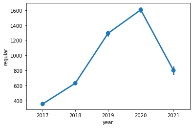

```python
sns.pointplot(data=df, x='year', y='regular')
```

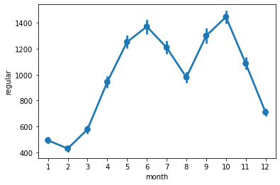

```python
sns.pointplot(data=df, x='month', y='regular')
```

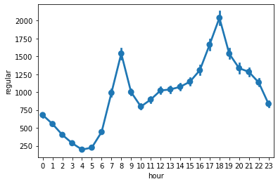

```python
sns.pointplot(data=df, x='hour', y='regular')
```

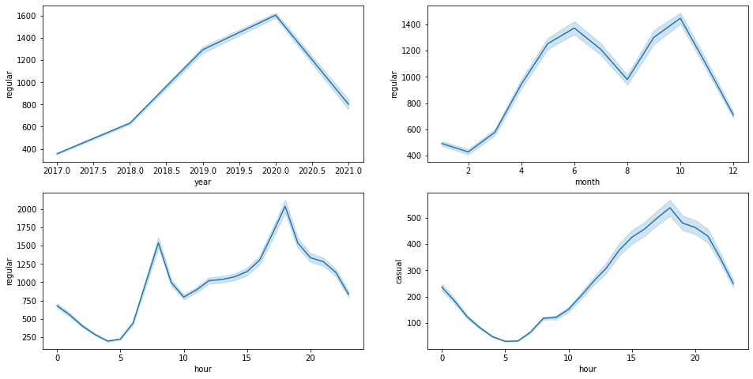

```python
import matplotlib.pyplot as plt

fig, ((ax1, ax2), (ax3, ax4)) = plt.subplots(ncols=2, nrows=2)

fig.set_size_inches(16, 8)

sns.lineplot(data=df, x='year', y='regular', ax=ax1)
sns.lineplot(data=df, x='month', y='regular', ax=ax2)
sns.lineplot(data=df, x='hour', y='regular', ax=ax3)
sns.lineplot(data=df, x='hour', y='casual', ax=ax4)
```

```python
df['weekend'] = 0
df.loc[df['dayofweek'] > 4, 'weekend'] = 1

# 공휴일에 대한 정보도 추가해서 확인해볼 것
```

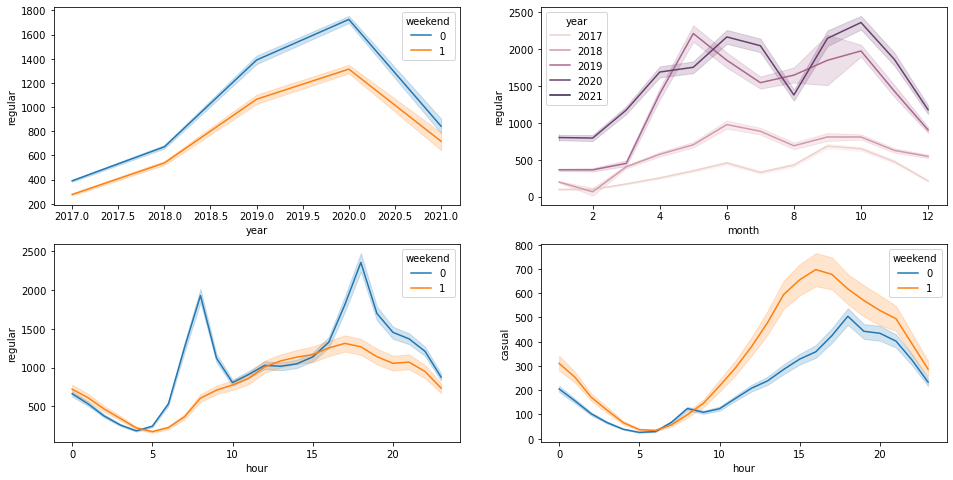

```python
fig, ((ax1, ax2), (ax3, ax4)) = plt.subplots(ncols=2, nrows=2)

fig.set_size_inches(16, 8)

sns.lineplot(data=df, x='year', y='regular', hue='weekend', ax=ax1)
sns.lineplot(data=df, x='month', y='regular', hue='year', ax=ax2)
sns.lineplot(data=df, x='hour', y='regular', hue='weekend', ax=ax3)
sns.lineplot(data=df, x='hour', y='casual', hue='weekend', ax=ax4)
```

## Data Preparation

- 이상치 탐지: MAD 방식
- scaling: Robust Scaling + 타 Scaling 방식과의 차이
- feature selection: permutaion importance

#### 이상치 탐지: MAD 방식

- Median Absolute deviation, 중앙값 절대 편차
- Median: 1등 ~ 꼴등 중에서 중간 등수의 점수

```python
med = np.median(df['regular'])
med
```

```
606.0
```

```python
med_dist = np.abs(df['regular'] - med)
med_dist
```

```
0        543.0
1        551.0
2        568.0
3        584.0
4        590.0
         ...
32098    740.0
32099    692.0
32100    623.0
32101    144.0
32102    110.0
Name: regular, Length: 32103, dtype: float64
```

```python
MAD = np.median(med_dist)
MAD
```

```
441.0
```

```python
modified_z = 0.6745 * med_dist / MAD
modified_z
```

```
0        0.830507
1        0.842743
2        0.868744
3        0.893215
4        0.902392
           ...
32098    1.131814
32099    1.058399
32100    0.952865
32101    0.220245
32102    0.168243
Name: regular, Length: 32103, dtype: float64
```

```python
df.loc[modified_z >= 3.5]
```

|  | year | month | day | hour | dayofweek | windforce | discomfort | heat_stroke | regular | casual | group | weekend |
| --- | --- | --- | --- | --- | --- | --- | --- | --- | --- | --- | --- | --- |
| 17245 | 2019 | 4 | 10 | 18 | 2 | 0 | 0 | 0 | 3068.0 | 375.0 | 8.0 | 0 |
| 17260 | 2019 | 4 | 11 | 8 | 3 | 0 | 0 | 0 | 3240.0 | 156.0 | 1.0 | 0 |
| 17270 | 2019 | 4 | 11 | 18 | 3 | 0 | 0 | 0 | 3586.0 | 667.0 | 12.0 | 0 |
| 17284 | 2019 | 4 | 12 | 8 | 4 | 0 | 0 | 0 | 3142.0 | 178.0 | 0.0 | 0 |
| 17285 | 2019 | 4 | 12 | 8 | 4 | 0 | 0 | 0 | 3142.0 | 178.0 | 0.0 | 0 |
| ... | ... | ... | ... | ... | ... | ... | ... | ... | ... | ... | ... | ... |
| 31930 | 2021 | 1 | 25 | 8 | 0 | 0 | 0 | 0 | 2905.0 | 207.0 | 2.0 | 0 |
| 31939 | 2021 | 1 | 25 | 17 | 0 | 0 | 0 | 0 | 3149.0 | 1072.0 | 18.0 | 0 |
| 31940 | 2021 | 1 | 25 | 18 | 0 | 0 | 0 | 0 | 4042.0 | 1070.0 | 16.0 | 0 |
| 31984 | 2021 | 1 | 27 | 8 | 2 | 0 | 0 | 0 | 2901.0 | 189.0 | 0.0 | 0 |
| 31994 | 2021 | 1 | 27 | 18 | 2 | 0 | 0 | 0 | 3484.0 | 672.0 | 10.0 | 0 |

1959 rows × 12 columns

#### scaling: Robust Scaling + 타 Scaling 방식과의 차이

```python
df.describe()
```

|  | year | month | day | hour | dayofweek | windforce | discomfort | heat_stroke | regular | casual | group | weekend |
| --- | --- | --- | --- | --- | --- | --- | --- | --- | --- | --- | --- | --- |
| count | 32103.000000 | 32103.000000 | 32103.000000 | 32103.000000 | 32103.000000 | 32103.000000 | 32103.000000 | 32103.000000 | 32103.000000 | 32103.000000 | 32103.000000 | 32103.000000 |
| mean | 2018.579479 | 6.489144 | 15.821325 | 11.468461 | 3.033860 | 0.013176 | 0.195870 | 0.107498 | 975.419587 | 257.412859 | 7.736317 | 0.293680 |
| std | 1.233033 | 3.554054 | 8.722862 | 6.884515 | 2.011401 | 0.114031 | 0.462822 | 0.397253 | 1025.717240 | 373.839847 | 16.194257 | 0.455454 |
| min | 2017.000000 | 1.000000 | 1.000000 | 0.000000 | 0.000000 | 0.000000 | 0.000000 | 0.000000 | 0.000000 | 0.000000 | 0.000000 | 0.000000 |
| 25% | 2017.000000 | 3.000000 | 8.000000 | 6.000000 | 1.000000 | 0.000000 | 0.000000 | 0.000000 | 246.000000 | 33.000000 | 0.000000 | 0.000000 |
| 50% | 2019.000000 | 6.000000 | 16.000000 | 11.000000 | 3.000000 | 0.000000 | 0.000000 | 0.000000 | 606.000000 | 107.000000 | 2.000000 | 0.000000 |
| 75% | 2020.000000 | 10.000000 | 23.000000 | 17.000000 | 5.000000 | 0.000000 | 0.000000 | 0.000000 | 1353.500000 | 317.000000 | 7.000000 | 1.000000 |
| max | 2021.000000 | 12.000000 | 31.000000 | 23.000000 | 6.000000 | 1.000000 | 3.000000 | 3.000000 | 10196.000000 | 3237.000000 | 236.000000 | 1.000000 |

```python
df['regular_plus'] = df['regular'] + 1
interested = ['regular', 'regular_plus']
df[interested].describe()
```

|  | regular | regular_plus |
| --- | --- | --- |
| count | 32103.000000 | 32103.000000 |
| mean | 975.419587 | 976.419587 |
| std | 1025.717240 | 1025.717240 |
| min | 0.000000 | 1.000000 |
| 25% | 246.000000 | 247.000000 |
| 50% | 606.000000 | 607.000000 |
| 75% | 1353.500000 | 1354.500000 |
| max | 10196.000000 | 10197.000000 |

```python
df['regular_plus'] = df['regular'] - np.median(df['regular'])
interested = ['regular', 'regular_plus']
df[interested].describe()
```

|  | regular | regular_plus |
| --- | --- | --- |
| count | 32103.000000 | 32103.000000 |
| mean | 975.419587 | 369.419587 |
| std | 1025.717240 | 1025.717240 |
| min | 0.000000 | -606.000000 |
| 25% | 246.000000 | -360.000000 |
| 50% | 606.000000 | 0.000000 |
| 75% | 1353.500000 | 747.500000 |
| max | 10196.000000 | 9590.000000 |

```python
# 75%지점 - 25%지점
IQR_val = 1353.5 - 246

# robust
df['regular_rob'] = (df['regular'] - np.median(df['regular'])) / IQR_val

# standard
df['regular_std'] = (df['regular'] - np.mean(df['regular'])) / np.std(df['regular'])

interested = ['regular', 'regular_rob', 'regular_std']
df[interested].describe()
```

|  | regular | regular_rob | regular_std |
| --- | --- | --- | --- |
| count | 32103.000000 | 32103.000000 | 3.210300e+04 |
| mean | 975.419587 | 0.333562 | -1.080782e-15 |
| std | 1025.717240 | 0.926156 | 1.000016e+00 |
| min | 0.000000 | -0.547178 | -9.509782e-01 |
| 25% | 246.000000 | -0.325056 | -7.111423e-01 |
| 50% | 606.000000 | 0.000000 | -3.601629e-01 |
| 75% | 1353.500000 | 0.674944 | 3.686068e-01 |
| max | 10196.000000 | 8.659142 | 8.989538e+00 |

#### feature selection: permutaion importance

- 기초통계량: filter
- 기계학습: wrapper, embed, permutaion importance
- 원본 데이터였을 때와 순서를 섞었을 때 차이점을 이용해 변수를 선택
- 접근법: MCR, PIMP

#### MCR 접근법

- reference: Fisher (2019), All Models are Wrong, but many are useful

#### MCR 프로세스

1. 학습이 끝난 모델 f, X(feature 데이터 셋), y(label), 평가지표 준비
2. f에 대해서 f(X, y)적용하여 학습 후 평가지표 점수 확인, S라 함
3. feature 하나하나에 대하여 아래 내용 반복
- x에 대하여 j번째 feature를 선택하고, 이 feature 안의 데이터를 무작위로 섞은 Xj 만들기
- (Xj, y) 연결하여 모델 학습 및 평가지표 도출 -> Sj
- k회 반복 -> 5번 반복
- Sjk들을 모아서 S와 확인

```python
sample_df = pd.read_csv('test1_modify6.csv')
sample_df.describe().columns
```

```
Index(['year', 'month', 'day', 'hour', 'dayofweek', 'windforce', 'discomfort',
       'heat_stroke', 'regular', 'casual', 'group'],
      dtype='object')
```

```python
from sklearn.ensemble import RandomForestRegressor as rf
label = 'regular'
features = ['year', 'month', 'day', 'hour', 'dayofweek',
            'windforce', 'discomfort', 'heat_stroke']

X, y = sample_df[features], sample_df[label]
model = rf()
model.fit(X, y)
model.score(X, y)

# S 확인
```

```
0.9864405769765724
```

```python
label = 'regular'
features = ['year', 'month', 'day', 'hour', 'dayofweek',
            'windforce', 'discomfort', 'heat_stroke']

shuffle = sample_df['hour']
np.random.shuffle(shuffle)
sample_df['hour'] = shuffle
sample_df.head()
```

|  | year | month | day | hour | dayofweek | windforce | discomfort | heat_stroke | regular | casual | group |
| --- | --- | --- | --- | --- | --- | --- | --- | --- | --- | --- | --- |
| 0 | 2017 | 1 | 1 | 18 | 6 | 0 | 0 | 0 | 63.0 | 13.0 | 1.0 |
| 1 | 2017 | 1 | 1 | 7 | 6 | 0 | 0 | 0 | 55.0 | 21.0 | 0.0 |
| 2 | 2017 | 1 | 1 | 12 | 6 | 0 | 0 | 0 | 38.0 | 19.0 | 0.0 |
| 3 | 2017 | 1 | 1 | 19 | 6 | 0 | 0 | 0 | 22.0 | 12.0 | 0.0 |
| 4 | 2017 | 1 | 1 | 19 | 6 | 0 | 0 | 0 | 16.0 | 7.0 | 0.0 |

```python
X, y = sample_df[features], sample_df[label]
model = rf()
model.fit(X, y)
model.score(X, y)

# Sj 확인
# 0.98 -> 0.82로 점수가 떨어짐

# 모든 컬럼에 대해서 진행했을 때,
# 중요한 정보가 들어간 컬럼은 점수의 하락폭이 높을 것이고,
# 덜 중요한 정보가 들어간 컬럼은 점수 하락폭이 낮을 것임
```

```
0.8270846071377926
```

```python
from sklearn.inspection import permutation_importance as pi

df = pd.read_csv('test1_modify6.csv')
X, y = df[features], df[label]
model = rf()
model.fit(X, y)

result = pi(model, X, y)
```

```python
pd.DataFrame(result['importances'])
```

|  | 0 | 1 | 2 | 3 | 4 |
| --- | --- | --- | --- | --- | --- |
| 0 | 0.968350 | 0.954252 | 0.962444 | 0.956379 | 0.970503 |
| 1 | 0.639258 | 0.660137 | 0.660143 | 0.656407 | 0.657789 |
| 2 | 0.230138 | 0.227416 | 0.220065 | 0.229411 | 0.224201 |
| 3 | 0.858510 | 0.856596 | 0.856642 | 0.857383 | 0.838292 |
| 4 | 0.229035 | 0.228976 | 0.225719 | 0.223815 | 0.236298 |
| 5 | 0.006512 | 0.006462 | 0.007213 | 0.008457 | 0.006650 |
| 6 | 0.030273 | 0.029199 | 0.028010 | 0.028891 | 0.028524 |
| 7 | 0.011470 | 0.010847 | 0.010506 | 0.011340 | 0.010891 |

```python
perm_df = pd.DataFrame(result['importances']).T
perm_df.columns = features
perm_df
```

|  | year | month | day | hour | dayofweek | windforce | discomfort | heat_stroke |
| --- | --- | --- | --- | --- | --- | --- | --- | --- |
| 0 | 0.968350 | 0.639258 | 0.230138 | 0.858510 | 0.229035 | 0.006512 | 0.030273 | 0.011470 |
| 1 | 0.954252 | 0.660137 | 0.227416 | 0.856596 | 0.228976 | 0.006462 | 0.029199 | 0.010847 |
| 2 | 0.962444 | 0.660143 | 0.220065 | 0.856642 | 0.225719 | 0.007213 | 0.028010 | 0.010506 |
| 3 | 0.956379 | 0.656407 | 0.229411 | 0.857383 | 0.223815 | 0.008457 | 0.028891 | 0.011340 |
| 4 | 0.970503 | 0.657789 | 0.224201 | 0.838292 | 0.236298 | 0.006650 | 0.028524 | 0.010891 |

```python
perm_df.describe()
```

|  | year | month | day | hour | dayofweek | windforce | discomfort | heat_stroke |
| --- | --- | --- | --- | --- | --- | --- | --- | --- |
| count | 5.000000 | 5.000000 | 5.000000 | 5.000000 | 5.000000 | 5.000000 | 5.000000 | 5.000000 |
| mean | 0.962385 | 0.654747 | 0.226246 | 0.853485 | 0.228769 | 0.007059 | 0.028980 | 0.011011 |
| std | 0.007136 | 0.008805 | 0.004151 | 0.008528 | 0.004760 | 0.000837 | 0.000848 | 0.000392 |
| min | 0.954252 | 0.639258 | 0.220065 | 0.838292 | 0.223815 | 0.006462 | 0.028010 | 0.010506 |
| 25% | 0.956379 | 0.656407 | 0.224201 | 0.856596 | 0.225719 | 0.006512 | 0.028524 | 0.010847 |
| 50% | 0.962444 | 0.657789 | 0.227416 | 0.856642 | 0.228976 | 0.006650 | 0.028891 | 0.010891 |
| 75% | 0.968350 | 0.660137 | 0.229411 | 0.857383 | 0.229035 | 0.007213 | 0.029199 | 0.011340 |
| max | 0.970503 | 0.660143 | 0.230138 | 0.858510 | 0.236298 | 0.008457 | 0.030273 | 0.011470 |

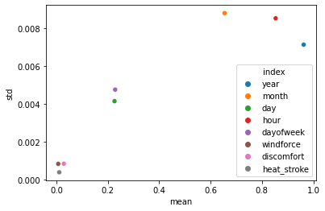

```python
interested = ['mean', 'std']
for_plot = perm_df.describe().T[interested].reset_index()
sns.scatterplot(data=for_plot, x='mean', y='std', hue='index')
```

#### PIMP 접근법

- reference: A Altmann (2010), Permutation Importance, https://academic.oup.com/bioinformatics/article/26/10/1340/193348
- embed 방식에서의 중요도 정보를 응용
- MCR처럼 평가지표로 하는게 아니고, 변수 중요도로 진행
- 알고리즘 학습하면 변수의 중요도를 알 수 있다.(random forest)

```python
from sklearn.ensemble import RandomForestRegressor as rf

df = pd.read_csv('test1_modify6.csv')
label = 'regular'
features = ['year', 'month', 'day', 'hour', 'dayofweek',
            'windforce', 'discomfort', 'heat_stroke']

X, y = df[features], df[label]
model = rf()
model.fit(X, y)
```

```
RandomForestRegressor()
```

```python
fi = pd.DataFrame()

fi['importance'] = model.feature_importances_
fi['feature'] = features

fi
```

|  | importance | feature |
| --- | --- | --- |
| 0 | 0.267007 | year |
| 1 | 0.238806 | month |
| 2 | 0.100682 | day |
| 3 | 0.303044 | hour |
| 4 | 0.067541 | dayofweek |
| 5 | 0.005269 | windforce |
| 6 | 0.011011 | discomfort |
| 7 | 0.006640 | heat_stroke |

#### PIMP 프로세스

1. 원본 데이터셋 X, y에 대해 학습해서 변수 중요도 P 산출
2. y의 순서를 섞음(yj) -> y를 섞으면 틀린 정답지를 가지고 학습하게 됨
3. 수정한 데이터셋 X, yj에 대해 학습하여 변수 중요도 Pj 산출
4. 2~3 단계 n회 반복
5. n개의 Pj에 대해 랜덤프로세스이므로 정규분포를 이룸
6. P가 Pj의 정규분포상 평균으로부터 몇 표준편차 떨어졌는가? 파악

```python
yj = pd.read_csv('test1_modify6.csv')[label]
np.random.shuffle(yj)
#yj

model = rf()
model.fit(X, yj)
model.feature_importances_

# Pj 산출
```

```
array([0.10048462, 0.14592445, 0.23069732, 0.34614968, 0.13750611,
       0.00480265, 0.02065815, 0.01377702])
```

```python
import warnings
warnings.simplefilter(action='ignore')
```

```python
yj = pd.read_csv('test1_modify6.csv')[label]
null_imp_df = pd.DataFrame()

for i in range(10):
    np.random.shuffle(yj)
    model = rf()
    model.fit(X, yj)
    null_imp_df[str(i) + '_shuffle'] = model.feature_importances_

null_imp_df
```

|  | 0_shuffle | 1_shuffle | 2_shuffle | 3_shuffle | 4_shuffle | 5_shuffle | 6_shuffle | 7_shuffle | 8_shuffle | 9_shuffle |
| --- | --- | --- | --- | --- | --- | --- | --- | --- | --- | --- |
| 0 | 0.101166 | 0.103356 | 0.102945 | 0.095603 | 0.094836 | 0.103466 | 0.095352 | 0.097940 | 0.104110 | 0.075679 |
| 1 | 0.144606 | 0.132034 | 0.131106 | 0.146983 | 0.126719 | 0.135622 | 0.141921 | 0.137906 | 0.156159 | 0.151990 |
| 2 | 0.221281 | 0.235584 | 0.245839 | 0.227455 | 0.236177 | 0.225767 | 0.206795 | 0.229475 | 0.231326 | 0.232740 |
| 3 | 0.363016 | 0.364425 | 0.339352 | 0.353841 | 0.360069 | 0.375579 | 0.381949 | 0.365872 | 0.343634 | 0.360348 |
| 4 | 0.136482 | 0.130215 | 0.144388 | 0.139153 | 0.146065 | 0.124774 | 0.136430 | 0.132505 | 0.129317 | 0.143464 |
| 5 | 0.004979 | 0.005388 | 0.005621 | 0.004425 | 0.005012 | 0.004837 | 0.004508 | 0.005443 | 0.005432 | 0.004839 |
| 6 | 0.016137 | 0.016291 | 0.016820 | 0.018104 | 0.017621 | 0.016644 | 0.019334 | 0.018068 | 0.019285 | 0.018073 |
| 7 | 0.012332 | 0.012707 | 0.013929 | 0.014436 | 0.013501 | 0.013313 | 0.013711 | 0.012790 | 0.010737 | 0.012867 |

```python
nulls = null_imp_df.T
nulls.columns = features
nulls
```

|  | year | month | day | hour | dayofweek | windforce | discomfort | heat_stroke |
| --- | --- | --- | --- | --- | --- | --- | --- | --- |
| 0_shuffle | 0.101166 | 0.144606 | 0.221281 | 0.363016 | 0.136482 | 0.004979 | 0.016137 | 0.012332 |
| 1_shuffle | 0.103356 | 0.132034 | 0.235584 | 0.364425 | 0.130215 | 0.005388 | 0.016291 | 0.012707 |
| 2_shuffle | 0.102945 | 0.131106 | 0.245839 | 0.339352 | 0.144388 | 0.005621 | 0.016820 | 0.013929 |
| 3_shuffle | 0.095603 | 0.146983 | 0.227455 | 0.353841 | 0.139153 | 0.004425 | 0.018104 | 0.014436 |
| 4_shuffle | 0.094836 | 0.126719 | 0.236177 | 0.360069 | 0.146065 | 0.005012 | 0.017621 | 0.013501 |
| 5_shuffle | 0.103466 | 0.135622 | 0.225767 | 0.375579 | 0.124774 | 0.004837 | 0.016644 | 0.013313 |
| 6_shuffle | 0.095352 | 0.141921 | 0.206795 | 0.381949 | 0.136430 | 0.004508 | 0.019334 | 0.013711 |
| 7_shuffle | 0.097940 | 0.137906 | 0.229475 | 0.365872 | 0.132505 | 0.005443 | 0.018068 | 0.012790 |
| 8_shuffle | 0.104110 | 0.156159 | 0.231326 | 0.343634 | 0.129317 | 0.005432 | 0.019285 | 0.010737 |
| 9_shuffle | 0.075679 | 0.151990 | 0.232740 | 0.360348 | 0.143464 | 0.004839 | 0.018073 | 0.012867 |

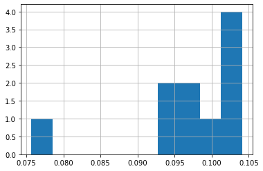

```python
nulls['year'].hist()
```

```python
interested = ['mean', 'std']
nulls = null_imp_df.T
nulls.columns = features
nulls = nulls.describe().T[interested].reset_index()

nulls['P'] = fi['importance'] # P
nulls['P_dist'] = (nulls['P'] - nulls['mean']) / nulls['std']
nulls
```

|  | index | mean | std | P | P_dist |
| --- | --- | --- | --- | --- | --- |
| 0 | year | 0.097445 | 0.008487 | 0.267007 | 19.978545 |
| 1 | month | 0.140505 | 0.009536 | 0.238806 | 10.307966 |
| 2 | day | 0.229244 | 0.010344 | 0.100682 | -12.428889 |
| 3 | hour | 0.360809 | 0.012967 | 0.303044 | -4.454684 |
| 4 | dayofweek | 0.136279 | 0.007097 | 0.067541 | -9.685216 |
| 5 | windforce | 0.005049 | 0.000411 | 0.005269 | 0.535338 |
| 6 | discomfort | 0.017638 | 0.001150 | 0.011011 | -5.760793 |
| 7 | heat_stroke | 0.013032 | 0.001027 | 0.006640 | -6.227264 |

```python
import time

t0 = time.time()
yj = pd.read_csv('test1_modify6.csv')[label]
null_imp_df = pd.DataFrame()

for i in range(1000):
    t1 = time.time() - t0
    if t1 > 600:
        break

    np.random.shuffle(yj)
    model = rf()
    model.fit(X, yj)
    null_imp_df[str(i) + '_shuffle'] = model.feature_importances_

null_imp_df
```